# R5.01 - Environnement économique : Économie des inégalités

Chapitre 2: Pourquoi (et faut-il) réduire les inégalités ?

Thomas Delcey

thomas.delcey@ube.fr

Université de Bourgogne Europe

### Le problème du chapitre

**Une inégalité ≠ injuste**

Il faut distinguer inégalité et injustice. Une inégalité est une différence entre des individus ou des groupes d’individus mais elle n’est pas forcément injuste.

Comment définir une inégalité injuste ou juste ?

### John Rawls et la justice sociale

**Définition : le voile d’ignorance**

Dans *Theory of Justice*, Rawls (1971) introduit l’idée du **voile d’ignorance** pour déterminer les principes d’une société juste.

- Il déduit des principes fondamentaux:
  - Le principe de liberté ;
  - Le principe d’égalité des chances ;
  - Le principe de différence.

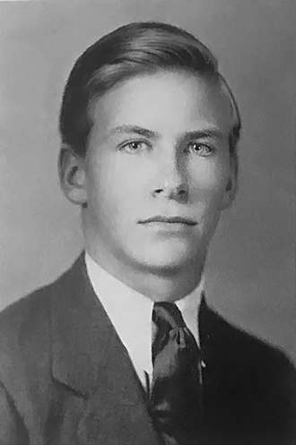

John Rawls (1921-2002)

### Application du « voile d’ignorance »

- Est-ce que ces situations d’inégalités sont justes au sens de Rawls ?

💼 Une personne a hérité de 200 000 euros pour payer ses études et lancer son entreprise. Ses camarades d’école de commerce se sont endettés pour payer leur étude.

⚕️En France, un médecin gagne en moyenne trois fois plus qu’un infirmier.

🏀 Victor mesure 2m26 et a un talent depuis l’enfance pour le basket. Il rejoint la NBA et devient le joueur le mieux payé de la ligue.

**Les inégalités naturelles sont injustes**

Pour Rawls, des différences de capacités “naturelles” (taille, intelligence, capacité physique, beauté, etc.) sont arbitrairement attribuées à certains individus et ne sont pas justes si elles ne profitent pas aux plus défavorisés.

### Au-delà de Rawls

**Important**

La théorie de Rawls n’est qu’un exemple, certes très influent, de théorie de la justice. Il existe une diversité de modèle pour penser les inégalités.

**Les autres théories de la justice sociale**

- Robert Nozick (1974) met l’accent sur les droits individuels et la propriété privée (exemple de Wilt Chamberlain 🏀). Selon lui, une inégalité de richesse est juste tant que l’acquisition et le transfert de cette richesse sont justes.
- Amartya Sen (1992) développe la théorie des capacités (*capabilities*) qui met l’accent sur les opportunités réelles des individus à mener une vie plutôt que sur la simple distribution des ressources matérielles. Cette conception est à la base de l’Indice de Développement Humain (IDH) des Nations Unies.

### Les arguments économiques

- Au-delà de la justice, le débat public mobilise d’autres arguments pour défendre ou critiquer les inégalités.

**Des arguments conséquentialistes**

Les inégalités ne sont pas un problème en soi, mais elles peuvent avoir des conséquences (positives ou négatives) sur l’économie et la société.

### Inégalité et bonheur

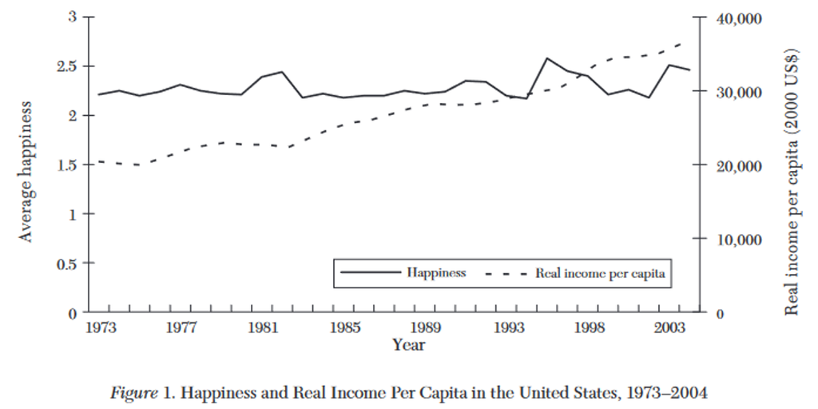

Graphique issue de Clark, Frijters, et Shields (2008). Relative income, happiness, and utility: “An explanation for the Easterlin paradox and other puzzles.” *Journal of Economic literature*, 46(1), 95-144.

### Inégalité et santé

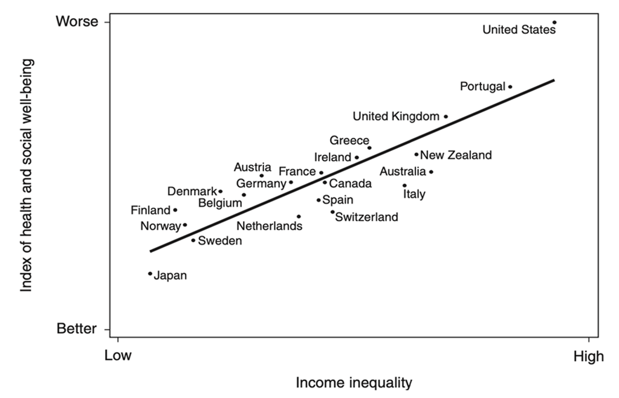

Figure issue de Wilkinson et Pickett (2010). *Spirit Level: Why Equality is Better for Everyone*.

Les pays les plus inégalitaires ont des indicateurs de santé publique plus faibles.

Attention à l’interprétation: absence d’axes, corrélation ≠ causalité, etc.

- En France (2020-2024), un homme parmi les 5 % les plus pauvres vit **13 ans de moins** qu’un homme parmi les 5 % les plus riches (72,0 ans contre 84,9 ans).
- Une femme parmi les 5 % les plus pauvres vit **8,7 ans de moins** qu’une femme parmi les 5 % les plus riches (80,1 ans contre 88,7 ans).

Source: Blanpain (2025) Première n° 2085, espérance de vie par niveau de vie 2020-2024.

### Inégalité et environnement

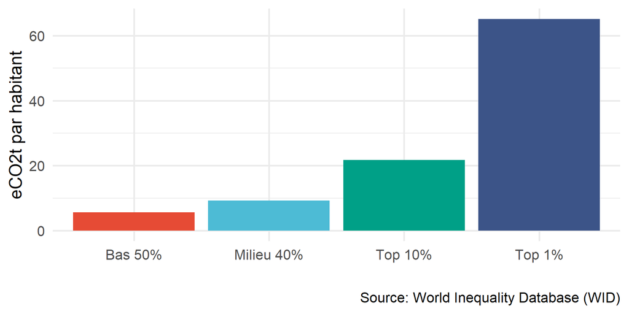

Empreinte carbone moyenne par habitant en France en 2019 selon le revenu

### Références

Blanpain, Nathalie. 2025. « De 2012-2016 à 2020-2024, l’écart d’espérance de vie entre les personnes modestes et aisées s’est accru ». Insee Première, n° 2085.

Clark, Andrew E., Paul Frijters, et Michael A. Shields. 2008. « Relative Income, Happiness, and Utility: An Explanation for the Easterlin Paradox and Other Puzzles ». *Journal of Economic Literature* 46 (1): 95‑144. https://doi.org/10.1257/jel.46.1.95.

Nozick, Robert. 1974. *Anarchy, State, and Utopia*. New York: Basic Books.

Rawls, John. 1971. *A Theory of Justice*. Cambridge, MA: Harvard University Press.

Sen, Amartya. 1992. *Inequality Reexamined*. Cambridge, MA: Harvard University Press.

Wilkinson, Richard, et Kate Pickett. 2010. *The Spirit Level: Why Equality is Better for Everyone*. London: Penguin Books.